# Project: Investigate the Dataset (Replace this with something more specific!)

10866 rows × 21 columns

> **Tip**: You should *not* perform too many operations in each cell. Create cells freely to explore your data. One option that you can take with this project is to do a lot of explorations in an initial notebook. These don't have to be organized, but make sure you use enough comments to understand the purpose of each code cell. Then, after you're done with your analysis, create a duplicate notebook where you will trim the excess and organize your steps so that you have a flowing, cohesive report.

> **Tip**: Make sure that you keep your reader informed on the steps that you are taking in your investigation. Follow every code cell, or every set of related code cells, with a markdown cell to describe to the reader what was found in the preceding cell(s). Try to make it so that the reader can then understand what they will be seeing in the following cell(s).

### Data Cleaning (1. Removing unnecessary columns)

```python
# After discussing the structure of the data and any problems that need to be
#   cleaned, perform those cleaning steps in the second part of this section.
# Exploring the names of the columns.
movies.columns
```

```
Index(['id', 'imdb_id', 'popularity', 'budget', 'revenue', 'original_title',
       'cast', 'homepage', 'director', 'tagline', 'keywords', 'overview',
       'runtime', 'genres', 'production_companies', 'release_date',
       'vote_count', 'vote_average', 'release_year', 'budget_adj',
       'revenue_adj'],
      dtype='object')
```

```python
# Removing unnecessary columns from the dataset.
movies.drop(['cast','homepage','director','tagline','keywords','overview','production_companies', 'id', 'imdb_id', 'popularity', 'budget_adj', 'revenue_adj', 'vote_count', 'release_year'], axis = 1, inplace=True)
movies.head()
```

|  | budget | revenue | original_title | runtime | genres | release_date | vote_average |
| --- | --- | --- | --- | --- | --- | --- | --- |
| 0 | 150000000 | 1513528810 | Jurassic World | 124 | Action\|Adventure\|Science Fiction\|Thriller | 6/9/15 | 6.5 |
| 1 | 150000000 | 378436354 | Mad Max: Fury Road | 120 | Action\|Adventure\|Science Fiction\|Thriller | 5/13/15 | 7.1 |
| 2 | 110000000 | 295238201 | Insurgent | 119 | Adventure\|Science Fiction\|Thriller | 3/18/15 | 6.3 |
| 3 | 200000000 | 2068178225 | Star Wars: The Force Awakens | 136 | Action\|Adventure\|Science Fiction\|Fantasy | 12/15/15 | 7.5 |
| 4 | 190000000 | 1506249360 | Furious 7 | 137 | Action\|Crime\|Thriller | 4/1/15 | 7.3 |

### Data Cleaning (2. Modifying some columns data types)

```python
# Modifying the release_date column data type to the correct type.
movies['release_date'] = pd.to_datetime(movies['release_date'])
movies.head()
```

|  | budget | revenue | original_title | runtime | genres | release_date | vote_average |
| --- | --- | --- | --- | --- | --- | --- | --- |
| 0 | 150000000 | 1513528810 | Jurassic World | 124 | Action\|Adventure\|Science Fiction\|Thriller | 2015-06-09 | 6.5 |
| 1 | 150000000 | 378436354 | Mad Max: Fury Road | 120 | Action\|Adventure\|Science Fiction\|Thriller | 2015-05-13 | 7.1 |
| 2 | 110000000 | 295238201 | Insurgent | 119 | Adventure\|Science Fiction\|Thriller | 2015-03-18 | 6.3 |
| 3 | 200000000 | 2068178225 | Star Wars: The Force Awakens | 136 | Action\|Adventure\|Science Fiction\|Fantasy | 2015-12-15 | 7.5 |
| 4 | 190000000 | 1506249360 | Furious 7 | 137 | Action\|Crime\|Thriller | 2015-04-01 | 7.3 |

### Data Cleaning (3. Removing duplicates)

```python
# Detecting if there are duplicates and their count.
movies.duplicated().sum()
```

```
1
```

```python
# Knowing the number of rows and columns of the dataframe before removing duplicates.
movies.shape
```

```
(10866, 7)
```

```python
# Removing duplicates from the dataframe.
movies.drop_duplicates(inplace=True)
movies.shape
```

```
(10865, 7)
```

### Data Cleaning (4. Removing missing values)

```python
# I noticed the presence of 0 values in many rows in the budget and revenue columns so I'll convert them all to null values
for column in movies.columns:
    movies[column] = movies[column].replace(0, np.nan)
```

```python
# Now checking for the missing values
movies.isna().sum()
```

```
budget            5696
revenue           6016
original_title       0
runtime             31
genres              23
release_date         0
vote_average         0
dtype: int64
```

```python
# And now removing all the rows with missing values
movies.dropna(inplace=True)
movies.shape
```

```
(3854, 7)
```

## Exploratory Data Analysis

> **Tip**: Now that you've trimmed and cleaned your data, you're ready to move on to exploration. Compute statistics and create visualizations with the goal of addressing the research questions that you posed in the Introduction section. It is recommended that you be systematic with your approach. Look at one variable at a time, and then follow it up by looking at relationships between variables.

### Research Question 1 (What are the movies that have the highest and lowest revenues?)

```python
# Use this, and more code cells, to explore your data. Don't forget to add
#   Markdown cells to document your observations and findings.
highest_revenue = max(movies['revenue'])
lowest_revenue = min(movies['revenue'])
highest_rev_movie = movies['original_title'].loc[movies['revenue'] == highest_revenue].iloc[0]
lowest_rev_movie = movies['original_title'].loc[movies['revenue'] == lowest_revenue].iloc[0]
print('The movie "{}" has the highest revenue with {}$, while the movie "{}" has the lowest revenue with {}$.'.format(highest_rev_movie, highest_revenue, lowest_rev_movie, lowest_revenue))
```

```
The movie "Avatar" has the highest revenue with 2781505847.0$, while the movie "Shattered Glass" has the lowest revenue with 2.0$.
```

### Research Question 2 (What are the movies that have the highest and lowest budgets?)

```python
# Continue to explore the data to address your additional research
#   questions. Add more headers as needed if you have more questions to
#   investigate.
highest_budget = max(movies['budget'])
lowest_budget = min(movies['budget'])
highest_budg_movie = movies['original_title'].loc[movies['budget'] == highest_budget].iloc[0]
lowest_budg_movie = movies['original_title'].loc[movies['budget'] == lowest_budget].iloc[0]
print('The movie "{}" has the highest budget with {}$, while the movie "{}" has the lowest budget with {}$.'.format(highest_budg_movie, highest_budget, lowest_budg_movie, lowest_budget))
```

```
The movie "The Warrior's Way" has the highest budget with 425000000.0$, while the movie "Lost & Found" has the lowest budget with 1.0$.
```

### Research Question 3 (What are the highest and lowest profitable movies?)

```python
# Calculating profits
movies['profits'] = movies['revenue'] - movies['budget']

# Determining the movies with highest and lowest profits
highest_profits = max(movies['profits'])
lowest_profits = min(movies['profits'])
highest_proft_movie = movies['original_title'].loc[movies['profits'] == highest_profits].iloc[0]
lowest_proft_movie = movies['original_title'].loc[movies['profits'] == lowest_profits].iloc[0]
print('The movie "{}" has the highest profits with {}$, while the movie "{}" has the lowest profits with {}$.'.format(highest_proft_movie, highest_profits, lowest_proft_movie, lowest_profits))
```

```
The movie "Avatar" has the highest profits with 2544505847.0$, while the movie "The Warrior's Way" has the lowest profits with -413912431.0$.
```

### Research Question 4 (What are the genres of the top 10 profitable movies?)

```python
# Sorting the movies according to the profits indicating their genres
top_genres = movies.sort_values('profits', ascending=False)['genres']
top_genres.head(10)
```

```
1386     Action|Adventure|Fantasy|Science Fiction
3        Action|Adventure|Science Fiction|Fantasy
5231                       Drama|Romance|Thriller
0       Action|Adventure|Science Fiction|Thriller
4                           Action|Crime|Thriller
4361             Science Fiction|Action|Adventure
3374                     Adventure|Family|Fantasy
14               Action|Adventure|Science Fiction
5422                   Animation|Adventure|Family
8094          Crime|Drama|Mystery|Thriller|Action
Name: genres, dtype: object
```

### Research Question 5 (What are the most profitable genres?)

```python
# Calculating the profits mean of all movies
profits_means = movies['profits'].mean()
profits_means
```

```
70482919.14322782
```

```python
# Creating a new dataframe containing the profitable movies with profits equals to or larger than the profits mean
profitable_movies = movies[movies['profits'] >= profits_means]

# Reindexing the new dataframe
profitable_movies.index = range(len(profitable_movies))

# Previewing the new dataframe
profitable_movies.head()
```

|  | budget | revenue | original_title | runtime | genres | release_date | vote_average | profits |
| --- | --- | --- | --- | --- | --- | --- | --- | --- |
| 0 | 150000000.0 | 1.513529e+09 | Jurassic World | 124.0 | Action\|Adventure\|Science Fiction\|Thriller | 2015-06-09 | 6.5 | 1.363529e+09 |
| 1 | 150000000.0 | 3.784364e+08 | Mad Max: Fury Road | 120.0 | Action\|Adventure\|Science Fiction\|Thriller | 2015-05-13 | 7.1 | 2.284364e+08 |
| 2 | 110000000.0 | 2.952382e+08 | Insurgent | 119.0 | Adventure\|Science Fiction\|Thriller | 2015-03-18 | 6.3 | 1.852382e+08 |
| 3 | 200000000.0 | 2.068178e+09 | Star Wars: The Force Awakens | 136.0 | Action\|Adventure\|Science Fiction\|Fantasy | 2015-12-15 | 7.5 | 1.868178e+09 |
| 4 | 190000000.0 | 1.506249e+09 | Furious 7 | 137.0 | Action\|Crime\|Thriller | 2015-04-01 | 7.3 | 1.316249e+09 |

```python
# Categories of profitable genres
profitable_movies['genres'].value_counts()
```

```
Comedy                                             63
Drama                                              48
Comedy|Romance                                     39
Drama|Romance                                      22
Comedy|Drama|Romance                               19
Adventure|Action|Thriller                          19
Action|Thriller                                    17
Comedy|Drama                                       15
Animation|Family                                   13
Horror                                             12
Adventure|Action|Science Fiction                   10
Action|Adventure|Science Fiction                    9
Adventure|Fantasy|Action                            9
Animation|Comedy|Family                             9
Horror|Thriller                                     9
Crime|Drama|Thriller                                9
Action|Adventure|Thriller                           8
Adventure|Fantasy|Family                            8
Comedy|Crime                                        8
Comedy|Family                                       8
Comedy|Romance|Drama                                8
Action|Thriller|Science Fiction                     8
Horror|Mystery                                      7
Adventure|Action|Thriller|Science Fiction           7
Action|Comedy                                       7
Action|Science Fiction                              6
Action|Thriller|Crime                               6
Action|Drama|Thriller                               6
Romance|Comedy                                      6
Drama|Comedy|Romance                                6
                                                   ..
Drama|Fantasy|Horror                                1
History                                             1
Fantasy|Adventure|Action|Family|Romance             1
Drama|Adventure|Romance|Thriller                    1
Drama|Action|Thriller|War                           1
Drama|Fantasy|Romance|Science Fiction               1
Action|Drama|History|War                            1
Drama|History|Thriller                              1
Animation|Action|Comedy|Family                      1
Horror|Thriller|Science Fiction                     1
Science Fiction|Adventure|Family|Fantasy            1
Drama|Thriller|Mystery                              1
Fantasy|Adventure|Animation|Family                  1
Family|Fantasy|Adventure                            1
Drama|Western                                       1
Action|Fantasy                                      1
Crime|Action|Thriller                               1
Science Fiction|Comedy|Crime|Action                 1
Science Fiction|Action|Adventure|Fantasy|Comedy     1
Action|Drama|Thriller|War                           1
Action|Crime|Science Fiction|Thriller               1
Action|Crime|Comedy                                 1
Fantasy|Comedy|Romance                              1
Adventure|Action|Thriller|Crime|Mystery             1
Fantasy|Comedy|Animation|Science Fiction|Family     1
Action|Adventure|Drama|Romance                      1
Action|Crime|Drama|Comedy|Thriller                  1
Crime|Thriller|Action                               1
Drama|Action|Thriller|Science Fiction               1
Thriller|Horror|Mystery                             1
Name: genres, Length: 466, dtype: int64
```

```python
# I noticed the presence of mixed genres together, so I'll separate them to make the arrangement more accurate
arranged_proft_movies = profitable_movies['genres'].str.cat(sep = '|')

# Making pandas series and storing the values separately
arranged_proft_movies = pd.Series(arranged_proft_movies.split('|'))

# Arranging the profitable genres in descending order and assigining them to a new series
arranged_proft_genres = arranged_proft_movies.value_counts(ascending = False)

# Showing the profitable genres
arranged_proft_genres
```

```
Comedy             386
Action             385
Drama              368
Adventure          321
Thriller           312
Family             189
Romance            179
Science Fiction    177
Fantasy            166
Crime              146
Animation          107
Horror              91
Mystery             88
Music               42
War                 39
History             26
Western             13
Documentary          3
dtype: int64
```

**As shown above we can say that the most 5 profitable genres are Comedy, Action, Drama, Adventure then Thriller.**

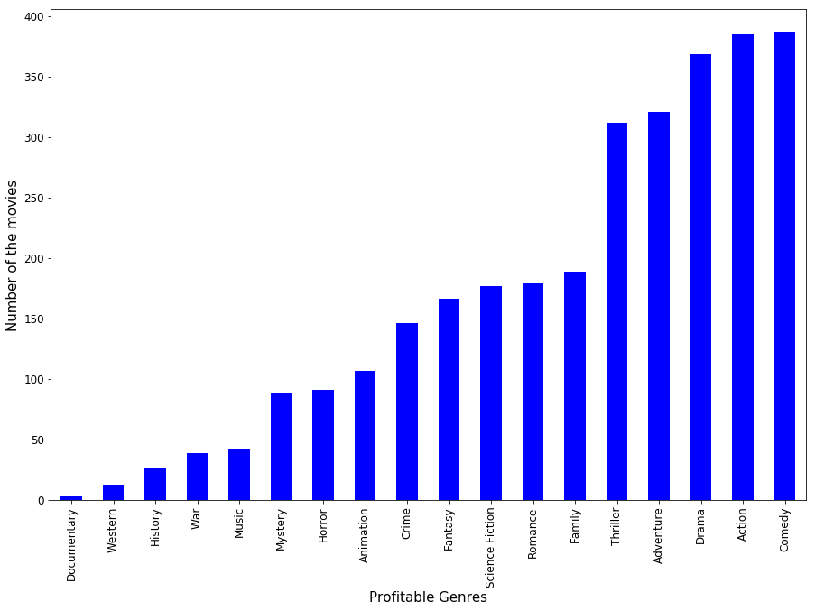

```python
# We can also show this in a graph as next:

arranged_proft_genres.sort_values(ascending = True, inplace = True)

# The Plot
lt = arranged_proft_genres.plot.bar(color = 'blue', fontsize = 12)

# y axis label
lt.set_ylabel('Number of the movies', fontsize = '15')

# x axis label
lt.set_xlabel('Profitable Genres', color = 'black', fontsize = '15')

# The figure size
lt.figure.set_size_inches(15, 10)
```

### Research Question 6 (Does the duration of the movie have a relation with its being profitable?)

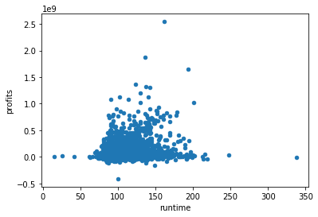

```python
# Drawing the relationship between the duration of the movie and its proftis
movies.plot.scatter(x='runtime', y='profits')
```

**Obviosuly, according the graph above, there's no real relationship between movies duration and its profits. However, the profitable movies have duration ranging from 70 to 200 minutes considering a profitable movies having a profit value larger than 70 millions dollar.**

### Research Question 7 (Does the movie budget have a relation with its being profitable?)

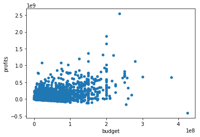

```python
# Drawing the relationship between the budget of the movie and its proftis
movies.plot.scatter(x='budget', y='profits')
```